# Michael Navarro: Competency 3 - Project 1

```python
#----------------------------------------------------------------------------------------
#                                       Imports
#----------------------------------------------------------------------------------------
import pandas as pd
import numpy as np
import seaborn as sns
import matplotlib.pyplot as plt

from scipy import stats

#----------------------------------- sklearn imports -----------------------------------
from sklearn.model_selection import cross_val_score, train_test_split
from sklearn.metrics import mean_squared_error
from sklearn.neighbors import KNeighborsRegressor
from sklearn.ensemble import GradientBoostingRegressor, RandomForestRegressor, VotingRegressor
from sklearn.linear_model import LinearRegression
from sklearn.model_selection import RandomizedSearchCV, GridSearchCV

#----------------------------------------------------------------------------------------
#                                   Global Constants
#----------------------------------------------------------------------------------------
# Relative path to dataset
BF_FPATH = 'datasets/bodyfat/bodyfat.csv'
```

# Load & Prepare The Data

The first thing to do is to load the data as a pandas dataframe. A brief description of the columns is also given to provide more context.

### ---------- Features ----------

```
Density
Age       |   (years)
Weight    |   (lbs)
Height    |   (inches)

Circumference of:
-----------------
Neck      |   (cm)
Chest     |   (cm)
Abdomen   |   (cm)
Hip       |   (cm)
Thigh     |   (cm)
Knee      |   (cm)
Ankle     |   (cm)
Biceps    |   (cm)
Forearm   |   (cm)
Wrist     |   (cm)
```

### ---------- Target ----------

```
Body Fat Percentage
```

```python
# Load bodyfat dataset
bodyfat = pd.read_csv(BF_FPATH)

# Create a list of just the features
all_feats = list(bodyfat.columns)
all_feats.remove('BodyFat')

# Peek at the first few rows
bodyfat.head()
```

|  | Density | BodyFat | Age | Weight | Height | Neck | Chest | Abdomen | Hip | Thigh | Knee | Ankle | Biceps | Forearm | Wrist |
| --- | --- | --- | --- | --- | --- | --- | --- | --- | --- | --- | --- | --- | --- | --- | --- |
| 0 | 1.0708 | 12.3 | 23 | 154.25 | 67.75 | 36.2 | 93.1 | 85.2 | 94.5 | 59.0 | 37.3 | 21.9 | 32.0 | 27.4 | 17.1 |
| 1 | 1.0853 | 6.1 | 22 | 173.25 | 72.25 | 38.5 | 93.6 | 83.0 | 98.7 | 58.7 | 37.3 | 23.4 | 30.5 | 28.9 | 18.2 |
| 2 | 1.0414 | 25.3 | 22 | 154.00 | 66.25 | 34.0 | 95.8 | 87.9 | 99.2 | 59.6 | 38.9 | 24.0 | 28.8 | 25.2 | 16.6 |
| 3 | 1.0751 | 10.4 | 26 | 184.75 | 72.25 | 37.4 | 101.8 | 86.4 | 101.2 | 60.1 | 37.3 | 22.8 | 32.4 | 29.4 | 18.2 |
| 4 | 1.0340 | 28.7 | 24 | 184.25 | 71.25 | 34.4 | 97.3 | 100.0 | 101.9 | 63.2 | 42.2 | 24.0 | 32.2 | 27.7 | 17.7 |

We will swap the target feature to be the first column in the dataset to have some sort of order and allow for easier data exploration when using list slicing.

```python
# Swap BodyFat and Desity Columns for data exploration
# !---------- Only Run Cell Once Per Notebook Runtime ----------!
cols = list(bodyfat.columns)
a, b = cols.index('BodyFat'), cols.index('Density')
cols[b], cols[a] = cols[a], cols[b]
bodyfat = bodyfat[cols]

bodyfat.head()
```

|  | BodyFat | Density | Age | Weight | Height | Neck | Chest | Abdomen | Hip | Thigh | Knee | Ankle | Biceps | Forearm | Wrist |
| --- | --- | --- | --- | --- | --- | --- | --- | --- | --- | --- | --- | --- | --- | --- | --- |
| 0 | 12.3 | 1.0708 | 23 | 154.25 | 67.75 | 36.2 | 93.1 | 85.2 | 94.5 | 59.0 | 37.3 | 21.9 | 32.0 | 27.4 | 17.1 |
| 1 | 6.1 | 1.0853 | 22 | 173.25 | 72.25 | 38.5 | 93.6 | 83.0 | 98.7 | 58.7 | 37.3 | 23.4 | 30.5 | 28.9 | 18.2 |
| 2 | 25.3 | 1.0414 | 22 | 154.00 | 66.25 | 34.0 | 95.8 | 87.9 | 99.2 | 59.6 | 38.9 | 24.0 | 28.8 | 25.2 | 16.6 |
| 3 | 10.4 | 1.0751 | 26 | 184.75 | 72.25 | 37.4 | 101.8 | 86.4 | 101.2 | 60.1 | 37.3 | 22.8 | 32.4 | 29.4 | 18.2 |
| 4 | 28.7 | 1.0340 | 24 | 184.25 | 71.25 | 34.4 | 97.3 | 100.0 | 101.9 | 63.2 | 42.2 | 24.0 | 32.2 | 27.7 | 17.7 |

The target has been succesfully swapped and the data looks the same so we are good to continue.

```python
# Display dataset info
bodyfat.info()
```

```
<class 'pandas.core.frame.DataFrame'>
RangeIndex: 252 entries, 0 to 251
Data columns (total 15 columns):
 #   Column   Non-Null Count  Dtype
---  ------   --------------  -----
 0   BodyFat  252 non-null    float64
 1   Density  252 non-null    float64
 2   Age      252 non-null    int64
 3   Weight   252 non-null    float64
 4   Height   252 non-null    float64
 5   Neck     252 non-null    float64
 6   Chest    252 non-null    float64
 7   Abdomen  252 non-null    float64
 8   Hip      252 non-null    float64
 9   Thigh    252 non-null    float64
 10  Knee     252 non-null    float64
 11  Ankle    252 non-null    float64
 12  Biceps   252 non-null    float64
 13  Forearm  252 non-null    float64
 14  Wrist    252 non-null    float64
dtypes: float64(14), int64(1)
memory usage: 29.7 KB
```

Using the info() method on the dataset shows that all columns are numerical and there are no NULL values found. This means we do not have to drop any rows due to NULL values. However, just to be safe, we will get a count of NULL values for every column using a different method for redundancies sake.

```python
# Count the number of NULL values in each column
bodyfat.isna().sum()
```

```
BodyFat    0
Density    0
Age        0
Weight     0
Height     0
Neck       0
Chest      0
Abdomen    0
Hip        0
Thigh      0
Knee       0
Ankle      0
Biceps     0
Forearm    0
Wrist      0
dtype: int64
```

The dataframe does not appear to have any NULL/NaN values. Let us continue and see how many outlier, if any, there are.

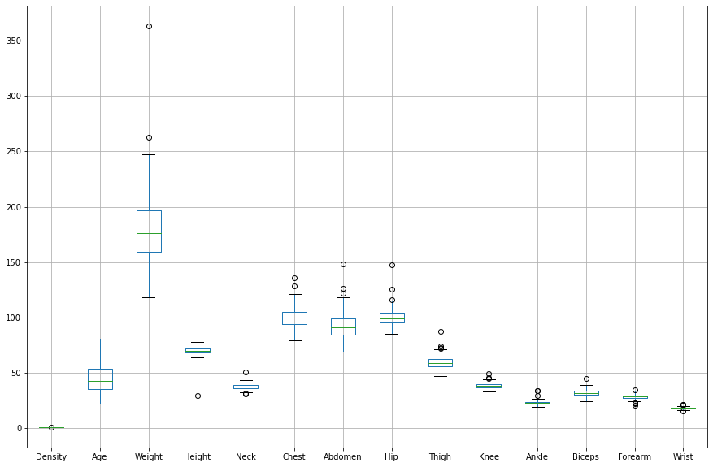

```python
# Boxplot to show outliers
bodyfat.boxplot(column=all_feats, figsize=(15, 10))
```

There are not a plethora of outliers, however, we should still git rid of some of them to get a cleaner set of data.

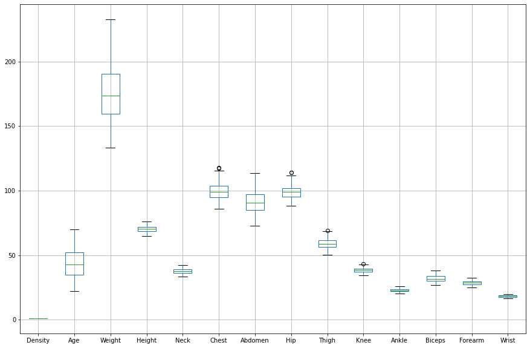

```python
# Normalize the data by removing anything above 2 std deviations using the z-score of each respective column
# I chose 2 std deviations becuase this is what I was taught in my statistics class is normal.
# We can switch to three if we want.
# 2 std deviations = 95% of data
# 3 std deviations = 99.7% of data
std_dev_cutoff = 2
bodyfat = bodyfat[(np.abs(stats.zscore(bodyfat[all_feats])) < std_dev_cutoff).all(axis=1)]

bodyfat.boxplot(column=all_feats, figsize=(15, 10))
```

Now that the outliers have been removed, let us ensure there are no duplicate rows in our dataset. Having duplicate rows is redundant, but not in a good way in this case.

```python
# Take a quick look at the number of rows
bodyfat.shape[0]
```

```
199
```

```python
# Drop duplicates and check number of rows afterwards
bodyfat.drop_duplicates(inplace=True)
bodyfat.shape[0]
```

```
199
```

Wile most of the columns appear to be in a similar scale, we will still normalize it to avoid any issues when determining which feature(s) are most important later on when tuning our model.

```python
# NOTE: I do not use the MinMaxScaler since it renames the columns however, I will leave it as an alternative
# from sklearn.preprocessing import MinMaxScaler
# minmax_scale = MinMaxScaler().fit_transform(bodyfat) #scale the dataframe to min 0 max 1
# bodyfat = pd.DataFrame(minmax_scale) # change the object back to dataframe form

# Normalize data
bodyfat = (bodyfat-bodyfat.min())/(bodyfat.max()-bodyfat.min())

bodyfat.describe() # now we see that the values of the attributes are on the same scale
```

|  | BodyFat | Density | Age | Weight | Height | Neck | Chest | Abdomen | Hip | Thigh | Knee | Ankle | Biceps | Forearm | Wrist |
| --- | --- | --- | --- | --- | --- | --- | --- | --- | --- | --- | --- | --- | --- | --- | --- |
| count | 199.000000 | 199.000000 | 199.000000 | 199.000000 | 199.000000 | 199.000000 | 199.000000 | 199.000000 | 199.000000 | 199.000000 | 199.000000 | 199.000000 | 199.000000 | 199.000000 | 199.000000 |
| mean | 0.518966 | 0.469522 | 0.452366 | 0.424820 | 0.496371 | 0.493704 | 0.433799 | 0.447420 | 0.415024 | 0.480099 | 0.458998 | 0.454235 | 0.469390 | 0.478224 | 0.471357 |
| std | 0.246239 | 0.244379 | 0.238424 | 0.210347 | 0.215582 | 0.222773 | 0.199556 | 0.199406 | 0.197025 | 0.212640 | 0.204594 | 0.208090 | 0.218240 | 0.217545 | 0.211187 |
| min | 0.000000 | 0.000000 | 0.000000 | 0.000000 | 0.000000 | 0.000000 | 0.000000 | 0.000000 | 0.000000 | 0.000000 | 0.000000 | 0.000000 | 0.000000 | 0.000000 | 0.000000 |
| 25% | 0.314381 | 0.275888 | 0.270833 | 0.266332 | 0.333333 | 0.329412 | 0.284810 | 0.295122 | 0.275391 | 0.341270 | 0.318681 | 0.303571 | 0.313043 | 0.305556 | 0.314286 |
| 50% | 0.528428 | 0.458580 | 0.437500 | 0.407035 | 0.488889 | 0.494118 | 0.420886 | 0.429268 | 0.414062 | 0.465608 | 0.461538 | 0.410714 | 0.434783 | 0.486111 | 0.485714 |
| 75% | 0.714047 | 0.663462 | 0.625000 | 0.576633 | 0.644444 | 0.629412 | 0.568038 | 0.592683 | 0.531250 | 0.603175 | 0.587912 | 0.598214 | 0.613043 | 0.645833 | 0.628571 |
| max | 1.000000 | 1.000000 | 1.000000 | 1.000000 | 1.000000 | 1.000000 | 1.000000 | 1.000000 | 1.000000 | 1.000000 | 1.000000 | 1.000000 | 1.000000 | 1.000000 | 1.000000 |

As can be seen, all the columns have been scaled to have a min value of 0 and a max value of 1.

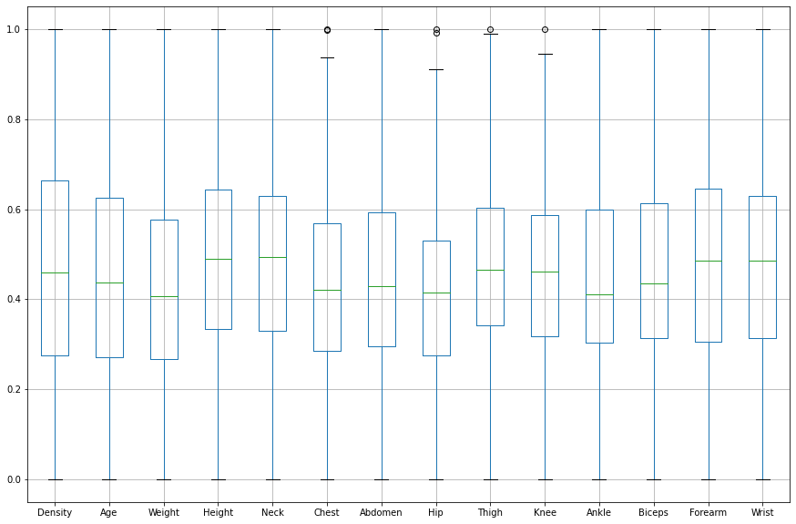

```python
# Boxplot to show outliers
bodyfat.boxplot(column=all_feats, figsize=(15, 10))
```

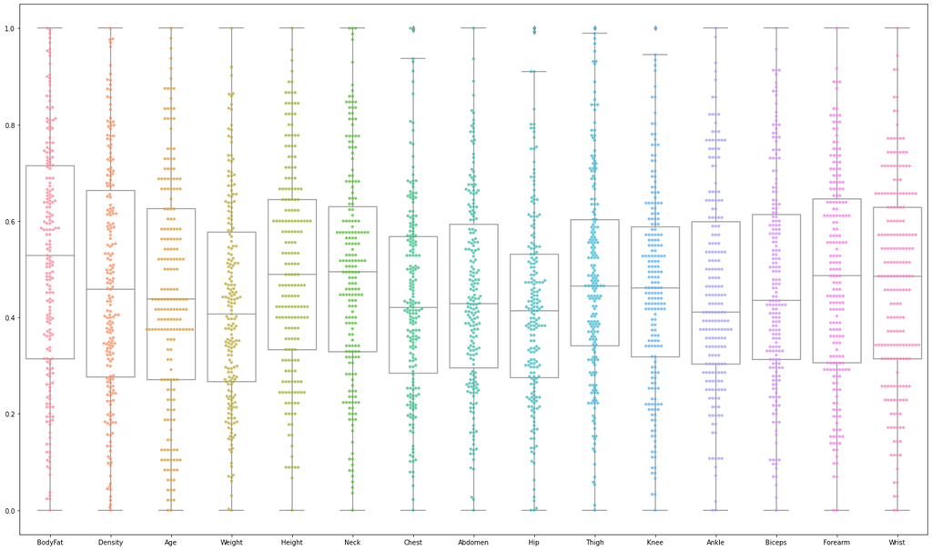

```python
# Combine boxplot and swarmplot to show outliers, spread of data points, and uniqueness of values in each column
plt.figure(figsize=(25, 15))
sns.boxplot(data=bodyfat, color='white') # color must be set to white to for visibility
sns.swarmplot(data=bodyfat, s=4.5, alpha=.75)
plt.show()
```

Veiwing the boxplot once more we can see a moe uniform spread of data and a lot less outliers. Furthermore, by combining a swarmplot with the boxplot we can get a nice visualization of where each features datapoints fall in relation to each other.

```python
# Get a count of number of unique values in each column
bodyfat.nunique()
```

```
BodyFat    145
Density    176
Age         47
Weight     154
Height      43
Neck        73
Chest      137
Abdomen    147
Hip        121
Thigh      112
Knee        72
Ankle       48
Biceps      87
Forearm     60
Wrist       34
dtype: int64
```

Using nunique() we can see the actual number of unqiue values per column. Considering we only have 199 rows after removing outliers, the fact that Density still has 176 unique values means almost every row has a unique Density value. This is very interesting because it means that rows could have very different values in the columns with the least amount of unique values, but still have very different Density values overall.

# Visualizing The Data

Now let us look at some visual representations of the datatset. First we will look at some pairplots in relation to the target. In order to make things more readable we will do two plots per different kind of plot.

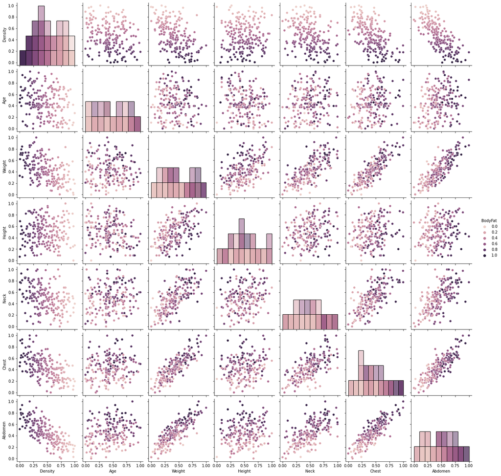

```python
# Take the first 8 columns and use the first column (BodyFat) as the hue variable
# Using iloc, we can take slices of the rows and columns.
# [:, :8] = All Rows and Columns 0-8
sns.pairplot(bodyfat.iloc[:, :8], kind='scatter', diag_kind='hist', hue='BodyFat')
```

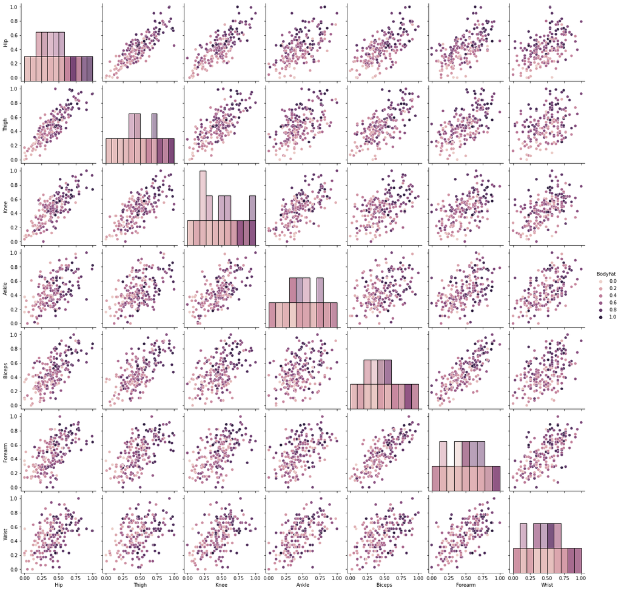

```python
# In order to include the target back we must do a slice concatenation using np.r_
#  Without this little trick we have to do a lot more column manipulation
sns.pairplot(bodyfat.iloc[:, np.r_[0, 8:15]], kind='scatter', diag_kind='hist', hue='BodyFat')
```

Using the target as the hue for the plots we can see that there is not an overwhelmingly clear predictor of the target, except for density. This may mean that density could be the only feature we need to take a look at when trying to predict someone's body fat accurately. However, there is some bodyfat variation within the density feature data.

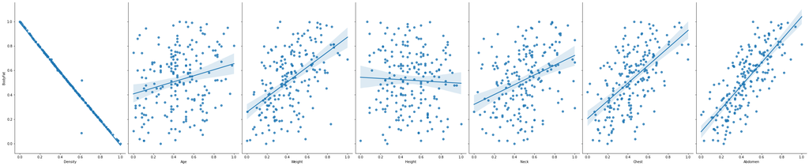

```python
sns.pairplot(bodyfat, x_vars=all_feats[:7], y_vars='BodyFat', height=7, aspect=0.7, kind='reg')
```

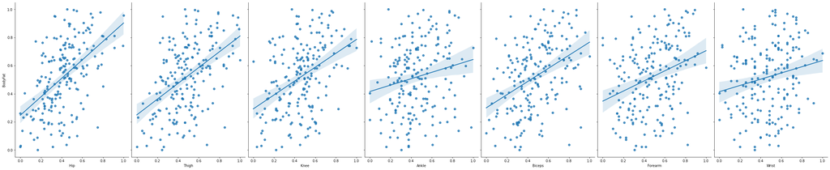

```python
sns.pairplot(bodyfat, x_vars=all_feats[7:14], y_vars='BodyFat', height=7, aspect=0.7, kind='reg')
```

With the preceeding regression plots we can see that, again, density is a very good predictor, but we also get an idea as to which other features are good predictors as well those being chest, abdoment, and hip with abdomen having the highest correlation.

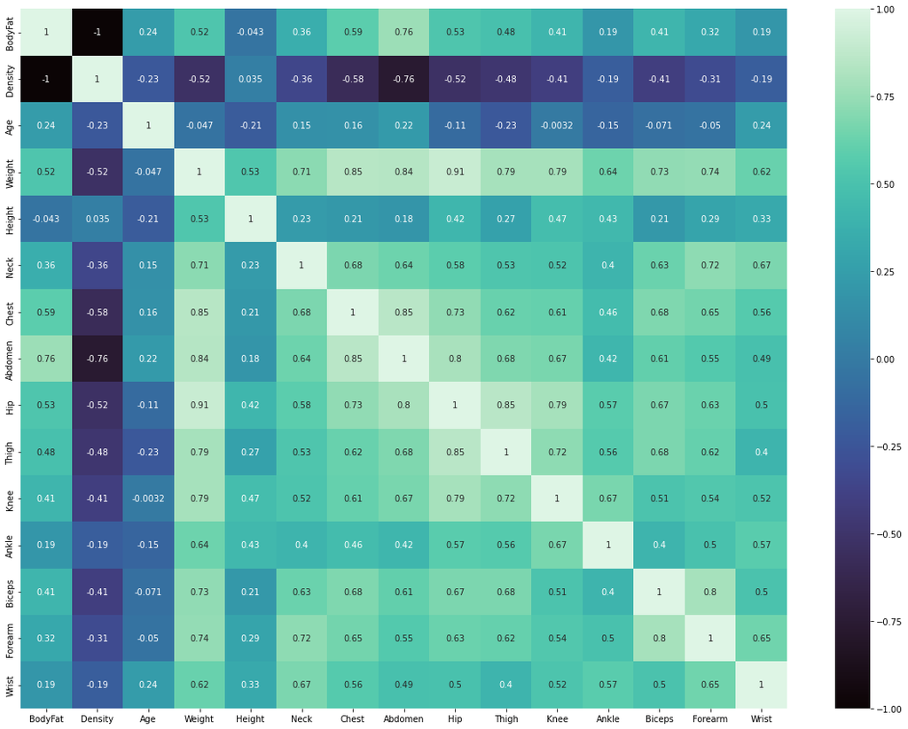

```python
corr = bodyfat.corr(method='pearson')
plt.figure(figsize=(20, 15))
sns.heatmap(corr, annot=True, vmin=-1, vmax=1, cmap='mako')
```

With this correlation heatmap we can see that the abdomen feature is the most correlated feature to the target, except for density.

# Define Training/Test Data

```python
# Choosing 'Abdomen' as the only feature from the feature matrix X and reshaping the array to 2 dimensions
X = bodyfat.iloc[:,7]
# We have to convert to a numpy array to avoid deprecation issues
X = np.array(X)[:,np.newaxis]

# Choosing 'target' as the response variable and reshaping the array to 2 dimensions
y = bodyfat.iloc[:,0]
# We have to convert to a numpy array to avoid deprecation issues
y = np.array(y)[:,np.newaxis]
```

```python
# Split the reduced dataset into training and test datasets
X_train, X_test, y_train, y_test = train_test_split(X, y, test_size=0.2, random_state=42)

# Shape of training datasets
print(X_train.shape)
print(y_train.shape)

# Shape of test datasets
print(X_test.shape)
print(y_test.shape)
```

```
(159, 1)
(159, 1)
(40, 1)
(40, 1)
```

# Model Selection And Training

## Linear Regression

```python
# These will be used for the remainder of the notebook
n_folds = 10
scoring = 'neg_mean_squared_error'
```

```python
# Defining Learning Model
models = [
    (LinearRegression(), 'LinearReg')
]

for model, model_name in models:
    model.fit(X_train,y_train)
    accuracy=model.score(X_test, y_test)
    cv_results = cross_val_score(model, X_train, y_train, scoring=scoring,cv=n_folds)

    # make predictions on the testing set
    y_pred= model.predict(X_test)

    print("%s\t| Accuracy=%f Mean=%f STD=%f" % (model_name, accuracy, cv_results.mean(), cv_results.std()))
    print('\t\t| Mean squared error: %.2f' % mean_squared_error(y_test, y_pred))
    print('\t\t| Root Mean squared error: %.2f' % np.sqrt(mean_squared_error(y_test, y_pred)))
    print("\t\t| y= a + bx -> a=model.intercept_=%f b=model.coef_=%f" %(model.intercept_, model.coef_))
# end for
```

```
LinearReg	| Accuracy=0.530157 Mean=-0.027213 STD=0.006480
		| Mean squared error: 0.02
		| Root Mean squared error: 0.14
		| y= a + bx -> a=model.intercept_=0.090308 b=model.coef_=0.944705
```

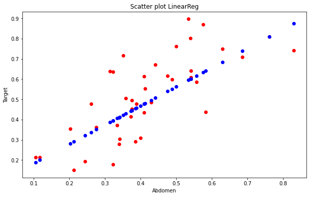

```python
# plotting the regression line on the scatter plot
plt.figure(figsize=(10,6))
plt.scatter(X_test, y_test,  color='r')
plt.scatter(X_test, y_pred, color='blue')
plt.title('Scatter plot '+ model_name)
plt.ylabel("Target")
plt.xlabel("Abdomen")
```

Using linear regression we get an accuracy of a little over 50%. While the model is technically able to predict the bodyfat percentage more than half the time, it will also be wrong almost half the number of times. Let us see if a different model using the same feature yields better results.

## KNNeaighbors

```python
models = [
    (KNeighborsRegressor(), 'KNNeighbors')
]

# Choosing 'Abdomen' as the only feature from the feature matrix X and reshaping the array to 2 dimensions
X = bodyfat.iloc[:,7]
# We have to convert to a numpy array to avoid deprecation issues
X = np.array(X)[:,np.newaxis]

# Choosing 'target' as the response variable and reshaping the array to 2 dimensions
y = bodyfat.iloc[:,0]
# We have to convert to a numpy array to avoid deprecation issues
y = np.array(y)[:,np.newaxis]

# Split the reduced dataset into training and test datasets
X_train, X_test, y_train, y_test = train_test_split(X, y, test_size=0.2, random_state=42)

for model, model_name in models:
    model.fit(X_train,y_train)
    accuracy=model.score(X_test, y_test)
    cv_results = cross_val_score(model, X_train, y_train, scoring=scoring,cv=n_folds)

    # make predictions on the testing set
    y_pred= model.predict(X_test)

    print("%s\t| Accuracy=%f Mean=%f STD=%f" % (model_name, accuracy, cv_results.mean(), cv_results.std()))
    print('\t\t| Mean squared error: %.2f' % mean_squared_error(y_test, y_pred))
    print('\t\t| Root Mean squared error: %.2f' % np.sqrt(mean_squared_error(y_test, y_pred)))
# end for
```

```
KNNeighbors	| Accuracy=0.461025 Mean=-0.031494 STD=0.006138
		| Mean squared error: 0.02
		| Root Mean squared error: 0.15
```

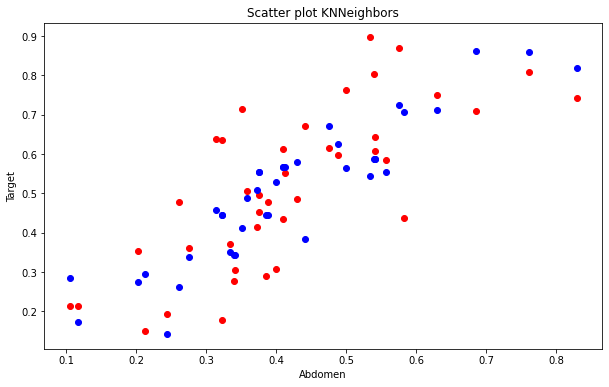

```python
plt.figure(figsize=(10,6))
plt.scatter(X_test, y_test,  color='r')
plt.scatter(X_test, y_pred, color='blue')
plt.title('Scatter plot '+ model_name)
plt.ylabel("Target")
plt.xlabel("Abdomen")
```

Unfortunately, using a KNN model actually decreased our accuracy score to be below 50%. Lets repeat the whole process using all the features.

```
MultiLinearReg	| Accuracy=0.998666 Mean=-0.000822 STD=0.001737
		| Mean squared error: 0.00
		| Root Mean squared error: 0.01
```

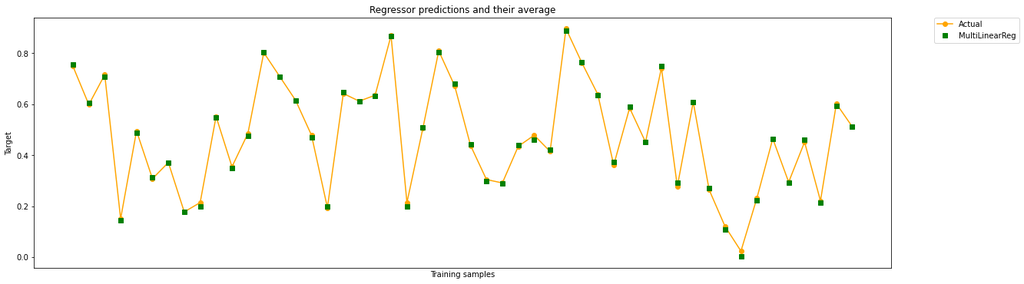

```
KNNeighbors	| Accuracy=0.803423 Mean=-0.012386 STD=0.003741
		| Mean squared error: 0.01
		| Root Mean squared error: 0.09
```

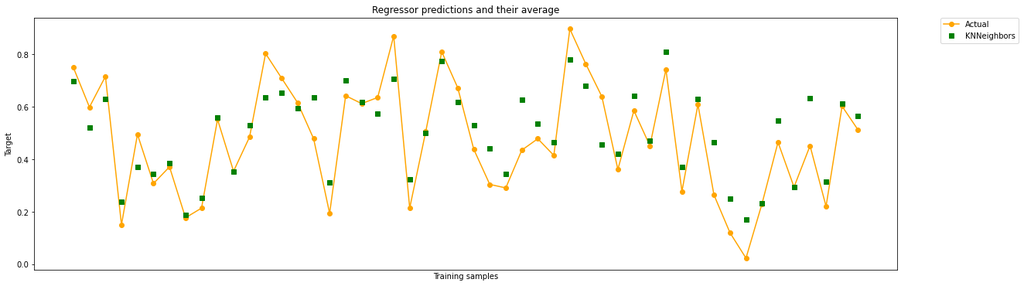

```python
# Everything except target variable
X = bodyfat.drop('BodyFat', axis=1)

# Target variable
y = bodyfat['BodyFat'].values

# Split the dataset
X_train, X_test, y_train, y_test = train_test_split(X, y, random_state=42)

# Defining Learning Model
models = [
    (LinearRegression(), 'MultiLinearReg'),
    (KNeighborsRegressor(), 'KNNeighbors')
]

for model, model_name in models:
    model.fit(X_train,y_train)
    accuracy=model.score(X_test, y_test)
    cv_results = cross_val_score(model, X_train, y_train, scoring=scoring,cv=n_folds)

    # make predictions on the testing set
    y_pred= model.predict(X_test)

    print("%s\t| Accuracy=%f Mean=%f STD=%f" % (model_name, accuracy, cv_results.mean(), cv_results.std()))
    print('\t\t| Mean squared error: %.2f' % mean_squared_error(y_test, y_pred))
    print('\t\t| Root Mean squared error: %.2f' % np.sqrt(mean_squared_error(y_test, y_pred)))

    plt.figure(figsize=(20,6))
    plt.plot(y_test, color='orange', marker='o', label='Actual')
    plt.plot(y_pred, 'gs', label=model_name)

    plt.tick_params(axis='x', which='both', bottom=False, top=False, labelbottom=False)
    plt.ylabel('Target')
    plt.xlabel('Training samples')
    plt.legend(bbox_to_anchor=(1.05, 1), loc='upper left', borderaxespad=0.)
    plt.title('Regressor predictions and their average')

    plt.show()
# end for
```

Using all the features has yielded incredible results. However, it has become clear that linear regression,specifically multi-linear regression, is better suited to this dataset than KNN. As such, my model of choice for this dataset is multi-linear regression.

# Fine-tuning The Model

```python
# Train classifiers
# Create a gradient boosting regressor, a random forest regressor and a linear regression.
# Then, we will use the 3 regressors to build the voting regressor:

gbr = GradientBoostingRegressor(random_state=1)
rfr = RandomForestRegressor(random_state=1)
mlr = LinearRegression()
ereg = VotingRegressor([('gb', gbr), ('rf', rfr), ('mlr', mlr)])

# Defining Learning Model
models = [
    (mlr, 'MLinearReg'),
    (gbr, 'GradientBReg'),
    (rfr,'RandomForestReg'),
    (ereg,'EnsembleReg')
]

for model, model_name in models:
    model.fit(X_train,y_train)
    accuracy=model.score(X_test, y_test)
    cv_results = cross_val_score(model, X_train, y_train, scoring=scoring,cv=n_folds)

    # make predictions on the testing set
    y_pred= model.predict(X_test)

    print("%s\t| Accuracy=%f Mean=%f STD=%f" % (model_name, accuracy, cv_results.mean(), cv_results.std()))
    print('\t\t| Mean squared error: %.2f' % mean_squared_error(y_test, y_pred))
    print('\t\t| Root Mean squared error: %.2f' % np.sqrt(mean_squared_error(y_test, y_pred)))
# end for
```

```
MLinearReg	| Accuracy=0.998666 Mean=-0.000822 STD=0.001737
		| Mean squared error: 0.00
		| Root Mean squared error: 0.01
GradientBReg	| Accuracy=0.999035 Mean=-0.001742 STD=0.002241
		| Mean squared error: 0.00
		| Root Mean squared error: 0.01
RandomForestReg	| Accuracy=0.998957 Mean=-0.001187 STD=0.002235
		| Mean squared error: 0.00
		| Root Mean squared error: 0.01
EnsembleReg	| Accuracy=0.999532 Mean=-0.001102 STD=0.002053
		| Mean squared error: 0.00
		| Root Mean squared error: 0.00
```

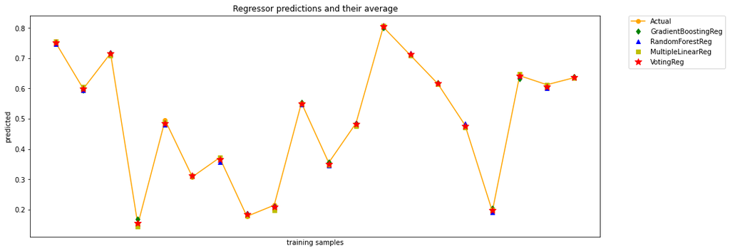

```python
# Visualizing the 20 predictions.
X_test = X_test[:20]
pred1 = gbr.predict(X_test)
pred2 = rfr.predict(X_test)
pred3 = mlr.predict(X_test)
pred4 = ereg.predict(X_test)


plt.figure(figsize=(15,6))
plt.plot(y_test[:20], color='orange', marker='o', label='Actual')
plt.plot(pred1, 'gd', label='GradientBoostingReg')
plt.plot(pred2, 'b^', label='RandomForestReg')
plt.plot(pred3, 'ys', label='MultipleLinearReg')
plt.plot(pred4, 'r*', ms=10, label='VotingReg')

plt.tick_params(axis='x', which='both', bottom=False, top=False, labelbottom=False)
plt.ylabel('predicted')
plt.xlabel('training samples')
plt.legend(bbox_to_anchor=(1.05, 1), loc='upper left', borderaxespad=0.)
plt.title('Regressor predictions and their average')

plt.show()
```

Fine tuning our model using ensemble regression (voting regression) yielded the best results as of yet with a solid 99.9% accuracy rating. Lets see if we can't fine tune our dataset at the same time by calculating the feature importance value of each feature.

```python
# Everything except target variable
X = bodyfat.drop('BodyFat', axis=1)

# Target variable
y = bodyfat['BodyFat'].values

param_grid = [
    # try 12 (3×4) combinations of hyperparameters
    {'n_estimators': [3, 10, 30], 'max_features': [2, 4, 6, 8]},
    # then try 6 (2×3) combinations with bootstrap set as False
    {'bootstrap': [False], 'n_estimators': [3, 10], 'max_features': [2, 3, 4]},
  ]

forest_reg = RandomForestRegressor(random_state=42)
# train across 5 folds, that's a total of (12+6)*5=90 rounds of training
grid_search = GridSearchCV(forest_reg, param_grid, cv=5,
                           scoring='neg_mean_squared_error',
                           return_train_score=True)
grid_search.fit(X, y)

param_distribs = {
        'n_estimators': stats.randint(low=1, high=200),
        'max_features': stats.randint(low=1, high=8),
    }

forest_reg = RandomForestRegressor(random_state=42)
rnd_search = RandomizedSearchCV(forest_reg, param_distributions=param_distribs,
                                n_iter=10, cv=5, scoring=scoring, random_state=42)
rnd_search.fit(X, y)

feature_importances = grid_search.best_estimator_.feature_importances_

feat_importance_tuples = sorted(zip(feature_importances, all_feats), reverse=True)
feat_importance_tuples
```

```
[(0.7290422835275593, 'Density'),
 (0.15079024818873496, 'Abdomen'),
 (0.042877453792858164, 'Chest'),
 (0.020489604964313707, 'Hip'),
 (0.013037037123582475, 'Weight'),
 (0.007735659792301882, 'Age'),
 (0.0068824135449584685, 'Height'),
 (0.005984989757430851, 'Ankle'),
 (0.005169080837545477, 'Neck'),
 (0.00442259132219994, 'Thigh'),
 (0.004212829170191585, 'Biceps'),
 (0.0034090394634399817, 'Wrist'),
 (0.0033191516302690078, 'Knee'),
 (0.0026276168846143186, 'Forearm')]
```

```python
top_feats = ['Density', 'Abdomen', 'Chest', 'Hip', 'Weight']
top_feats_agg_importance = 0
reg_feats_agg_importance = 0

for importance_value, feat_name in feat_importance_tuples:
    if feat_name in top_feats:
        top_feats_agg_importance += importance_value
    else:
        reg_feats_agg_importance += importance_value
    # end if
# end for

print(f'Total Importance Value of Density & Abdoment Features: {top_feats_agg_importance}')
print(f'Total Importance Value of Other Features: {reg_feats_agg_importance}')
```

```
Total Importance Value of Density & Abdoment Features: 0.9562366275970486
Total Importance Value of Other Features: 0.043763372402951514
```

We have created a new list of features from the five features with the highest importance values. Together, these features have a total importance value of around .956 on a scale from 0 to 1. Next, we will create a new tuned dataframe using just these features and running our models again. For science, we will include the KNN model again as a comparison, but also to see if there is any change.

```python
tuned_cols = top_feats.copy()
tuned_cols.append('BodyFat')

tuned_df = bodyfat[tuned_cols].copy()
tuned_df
```

|  | Density | Abdomen | Chest | Hip | Weight | BodyFat |
| --- | --- | --- | --- | --- | --- | --- |
| 0 | 0.677515 | 0.302439 | 0.224684 | 0.234375 | 0.211055 | 0.311037 |
| 1 | 0.892012 | 0.248780 | 0.240506 | 0.398438 | 0.402010 | 0.103679 |
| 2 | 0.242604 | 0.368293 | 0.310127 | 0.417969 | 0.208543 | 0.745819 |
| 3 | 0.741124 | 0.331707 | 0.500000 | 0.496094 | 0.517588 | 0.247492 |
| 4 | 0.133136 | 0.663415 | 0.357595 | 0.523438 | 0.512563 | 0.859532 |
| ... | ... | ... | ... | ... | ... | ... |
| 236 | 0.257396 | 0.619512 | 0.569620 | 0.492187 | 0.585427 | 0.729097 |
| 237 | 0.180473 | 1.000000 | 1.000000 | 0.910156 | 0.863317 | 0.812709 |
| 238 | 0.673077 | 0.243902 | 0.310127 | 0.234375 | 0.221106 | 0.314381 |
| 239 | 0.097633 | 0.675610 | 0.645570 | 0.468750 | 0.567839 | 0.899666 |
| 245 | 0.578402 | 0.280488 | 0.360759 | 0.230469 | 0.223618 | 0.408027 |

199 rows × 6 columns

```
MultiLinearReg	| Accuracy=0.999484 Mean=-0.000753 STD=0.001703
		| Mean squared error: 0.00
		| Root Mean squared error: 0.00
```

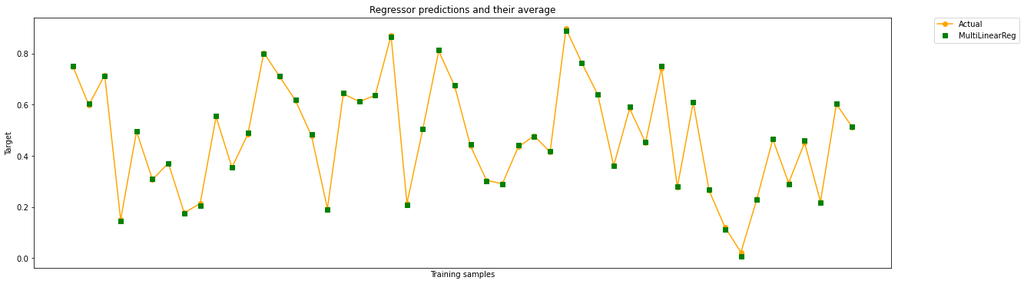

```
KNNeighbors	| Accuracy=0.942430 Mean=-0.004051 STD=0.001929
		| Mean squared error: 0.00
		| Root Mean squared error: 0.05
```

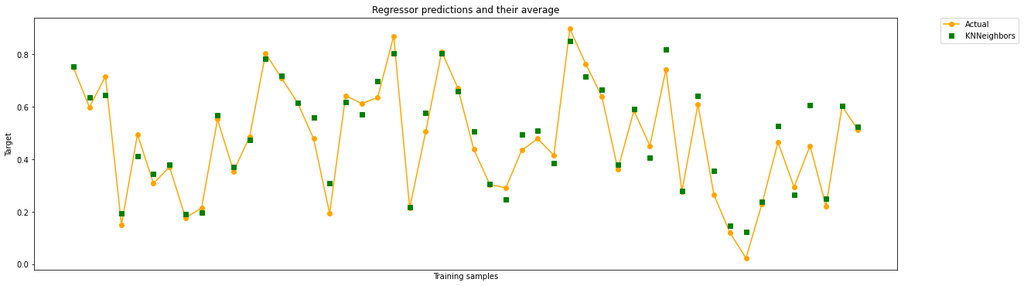

```python
# Everything except target variable
X = tuned_df.drop('BodyFat', axis=1)

# Target variable
y = tuned_df['BodyFat'].values

# Split the dataset
X_train, X_test, y_train, y_test = train_test_split(X, y, random_state=42)

# Defining Learning Model
models = [
    (LinearRegression(), 'MultiLinearReg'),
    (KNeighborsRegressor(), 'KNNeighbors')
]

for model, model_name in models:
    model.fit(X_train,y_train)
    accuracy=model.score(X_test, y_test)
    cv_results = cross_val_score(model, X_train, y_train, scoring=scoring,cv=n_folds)

    # make predictions on the testing set
    y_pred= model.predict(X_test)

    print("%s\t| Accuracy=%f Mean=%f STD=%f" % (model_name, accuracy, cv_results.mean(), cv_results.std()))
    print('\t\t| Mean squared error: %.2f' % mean_squared_error(y_test, y_pred))
    print('\t\t| Root Mean squared error: %.2f' % np.sqrt(mean_squared_error(y_test, y_pred)))

    plt.figure(figsize=(20,6))
    plt.plot(y_test, color='orange', marker='o', label='Actual')
    plt.plot(y_pred, 'gs', label=model_name)

    plt.tick_params(axis='x', which='both', bottom=False, top=False, labelbottom=False)
    plt.ylabel('Target')
    plt.xlabel('Training samples')
    plt.legend(bbox_to_anchor=(1.05, 1), loc='upper left', borderaxespad=0.)
    plt.title('Regressor predictions and their average')

    plt.show()
# end for
```

In an interesting turn of events, the accuracy of the KNN model increased by a large amount from when we were using the full feature set. In fact, it is almost 15% more accurate. Due to this, I must take back what I said about KNN not being a suitable model for this dataset.

```python
# Everything except target variable
X = tuned_df.drop('BodyFat', axis=1)

# Target variable
y = tuned_df['BodyFat'].values

# Split the dataset
X_train, X_test, y_train, y_test = train_test_split(X, y, random_state=42)

# Train classifiers
# Create a gradient boosting regressor, a random forest regressor and a linear regression.
# Then, we will use the 3 regressors to build the voting regressor:

gbr = GradientBoostingRegressor(random_state=1)
rfr = RandomForestRegressor(random_state=1)
mlr = LinearRegression()
ereg = VotingRegressor([('gb', gbr), ('rf', rfr), ('mlr', mlr)])

# Defining Learning Model
models = [
    (mlr, 'MLinearReg'),
    (gbr, 'GradientBReg'),
    (rfr,'RandomForestReg'),
    (ereg,'EnsembleReg')
]

for model, model_name in models:
    model.fit(X_train,y_train)
    accuracy=model.score(X_test, y_test)
    cv_results = cross_val_score(model, X_train, y_train, scoring=scoring,cv=n_folds)

    # make predictions on the testing set
    y_pred= model.predict(X_test)

    print("%s\t| Accuracy=%f Mean=%f STD=%f" % (model_name, accuracy, cv_results.mean(), cv_results.std()))
    print('\t\t| Mean squared error: %.2f' % mean_squared_error(y_test, y_pred))
    print('\t\t| Root Mean squared error: %.2f' % np.sqrt(mean_squared_error(y_test, y_pred)))
# end for
```

```
MLinearReg	| Accuracy=0.999484 Mean=-0.000753 STD=0.001703
		| Mean squared error: 0.00
		| Root Mean squared error: 0.00
GradientBReg	| Accuracy=0.997054 Mean=-0.001822 STD=0.002813
		| Mean squared error: 0.00
		| Root Mean squared error: 0.01
RandomForestReg	| Accuracy=0.998986 Mean=-0.001343 STD=0.002687
		| Mean squared error: 0.00
		| Root Mean squared error: 0.01
EnsembleReg	| Accuracy=0.999234 Mean=-0.001182 STD=0.002376
		| Mean squared error: 0.00
		| Root Mean squared error: 0.01
```

Using ensemble regression with the newly tuned dataset, we see that we have a minor drop in our accuracy, but it is still at 99.9%. Even though there was a small drop in acuracy, the benfit of using a cleaner more concise version of the datset can not be overlooked or dismissed. This holds especially true when considering the incredible accuracy gain when using the KNN model.

Using the metrics from the ensemble regression we can also see that there is no need to do ensemble regression with the tuned dataset since multi-linear regression actually outperforms ensemble regression.